# travail

SAMIRA

01/10/2019

Introduction:

La base de données vient de ramer_rater,elle S’appelle “ramen_ratings”. Elle regroupe differentes données sur les plats de nouilles qui viennent de differntes marques et de differents pays. On a 3180 observations au total et 6 variables.

```r
library(tidyverse)
library(RColorBrewer)
library(viridis)
```

#Visualisation des données

```r
summary(ramen_ratings)
```

```
##  review_number       brand             variety             style
##  Min.   :   1.0   Length:3180        Length:3180        Length:3180
##  1st Qu.: 795.5   Class :character   Class :character   Class :character
##  Median :1590.0   Mode  :character   Mode  :character   Mode  :character
##  Mean   :1590.1
##  3rd Qu.:2384.5
##  Max.   :3180.0
##  NA's   :1
##    country              stars
##  Length:3180        Min.   :0.000
##  Class :character   1st Qu.:3.250
##  Mode  :character   Median :3.750
##                     Mean   :3.688
##                     3rd Qu.:4.500
##                     Max.   :5.000
##                     NA's   :14
```

#1#La note moyenne pour chaque pays

```r
ramen_ratings %>%
group_by(country) %>%
summarise(note_moyenne = mean(stars, na.rm = T),
          note_min = min(stars, na.rm = T),
          note_max = max(stars, na.rm = T) )
```

```
## # A tibble: 44 x 4
##    country    note_moyenne note_min note_max
##    <chr>             <dbl>    <dbl>    <dbl>
##  1 Australia          3.26     1        5
##  2 Bangladesh         3.59     3        4
##  3 Brazil             4.04     3.5      5
##  4 Cambodia           4.2      3.5      5
##  5 Canada             2.26     0        5
##  6 China              3.47     0        5
##  7 Colombia           3.29     2.75     3.75
##  8 Dubai              3.58     3.25     3.75
##  9 Estonia            3.5      3.25     3.75
## 10 Fiji               3.88     3.25     4.25
## # ... with 34 more rows
```

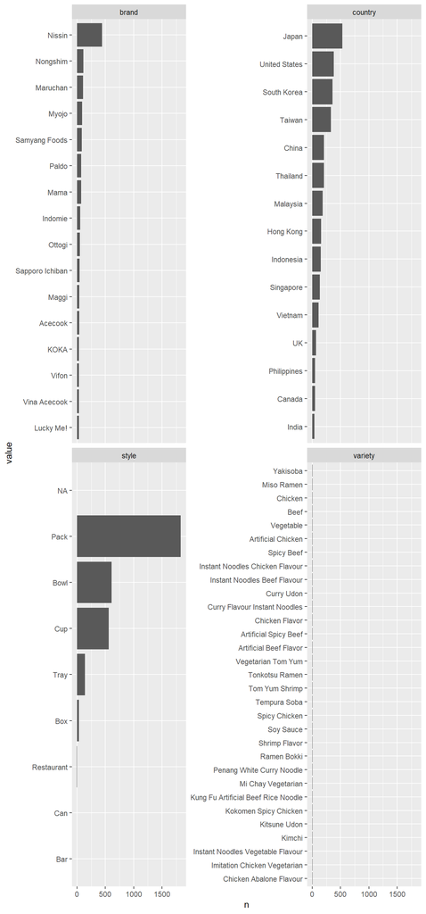

```r
ramen_ratings %>%
  gather(category,value, -review_number, -stars) %>%
  count(category, value) %>%
  group_by(category) %>%
  top_n(15,n) %>%
  ungroup() %>%
  mutate(value = fct_reorder(value,n)) %>%
  ggplot(aes(value,n)) +
  geom_col() +
  facet_wrap(~category, scales = "free_y") +
  coord_flip()
```

D’apres le résultats on a par exemple le Brésil qui a une note moyenne de 4.04 étoiles avec une note minimale de 3.5 étoiles et une note maximale de 5 étoiles.

#2#calculer le nombre de 5 étoiles obtenu par les ramens made in canada

```r
ramen_ratings %>%
filter(country == "Canada" & stars == 5) %>%
summarise(n = n())
```

```
## # A tibble: 1 x 1
##       n
##   <int>
## 1     2
```

Il n’y a que deux ramen fabriqués au Canada qui ont obtenus cinq étoiles.

```r
ramen_ratings %>%
  select(country, style, stars) %>%
filter(country == "Japan" |  country == "China")%>%
filter(stars == 5)
```

```
## # A tibble: 123 x 3
##    country style stars
##    <chr>   <chr> <dbl>
##  1 Japan   Tray      5
##  2 Japan   Pack      5
##  3 Japan   Cup       5
##  4 Japan   Bowl      5
##  5 Japan   Bowl      5
##  6 Japan   Pack      5
##  7 China   Box       5
##  8 China   Bowl      5
##  9 Japan   Cup       5
## 10 Japan   Pack      5
## # ... with 113 more rows
```

On remarque que le Japon a un nombre plus élevé de ramen qui ont eu 5 étoiles .

#4#classification des ramens les mieux notées en fonctin du style

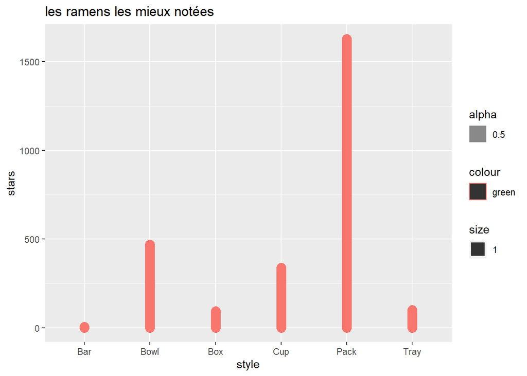

```r
ramen_ratings %>%
top_n(6, stars) %>%
  ggplot(aes(x = style, y = stars, color = "green", alpha = 0.5, size = 1)) +
  geom_area()+
  labs(title = "les ramens les mieux notées"  )
```